# Lecture 3: Plotting, Part 1 (base R)

Kelly and Gallego

One of the things people love about working in **R** is the ability to quickly make and change high-quality plots. And it’s true! Plotting is awesome and fun, and you will find yourself doing a bunch of it.

We’ll look mainly at plotting with the main **R** graphics (called “base **R**”), and also briefly preview a different set of plotting tools called **ggplot2** (which has a totally different syntax that can be confusing, but that makes great graphics. ggplot2 is part of a larger suite of tools known as the *tidyverse* or *tidyR*, which is super useful but super different from base **R**, so we’ll not mention it for now. Shhh…pretend we said nothing.)

Here again, we’ll use code from the *Pirate’s Guide*, and annotate it as necessary.

#### How to think about basic plotting in **R**

- A plot is like a canvas, and you can only work on one canvas at a time
- Some functions (like *plot()*) call entirely new canvases, others (like *points()*) add stuff to existing canvases
- The important thing isn’t the plot; it’s the code that made the plot. You can always quickly make a new graphic if you have the code.

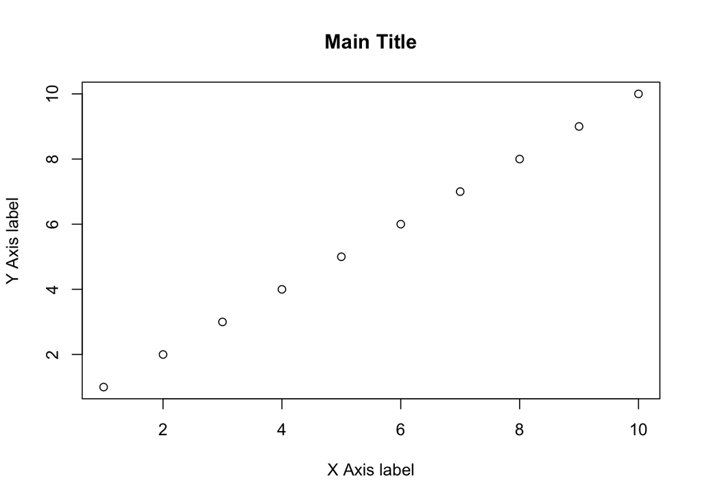

```r
# A basic scatterplot
plot(x = 1:10,  #this creates a vector from one to 10
     y = 1:10,  #this does the same
     xlab = "X Axis label",
     ylab = "Y Axis label",
     main = "Main Title")
```

Note that in the code we’ve specified the *x* and *y* variables (they are numeric vectors, in this case), and the *plot()* function knows we want to plot them against one another.

- If the vectors weren’t the same length, what would happen?

```r
plot(y=1:10, x=1:11)
```

```
## Error in xy.coords(x, y, xlabel, ylabel, log): 'x' and 'y' lengths differ
```

As seen above, it doesn’t make any sense to plot two vectors against one another if they aren’t the same length.

Note also that you can use *plot()* by specifying *x* and *y*, as above `plot(x = 1:10, y=1:10)` OR equivalently by using formula notation `plot(y~x)` if we’ve already defined *x* and *y* somewhere else. For example:

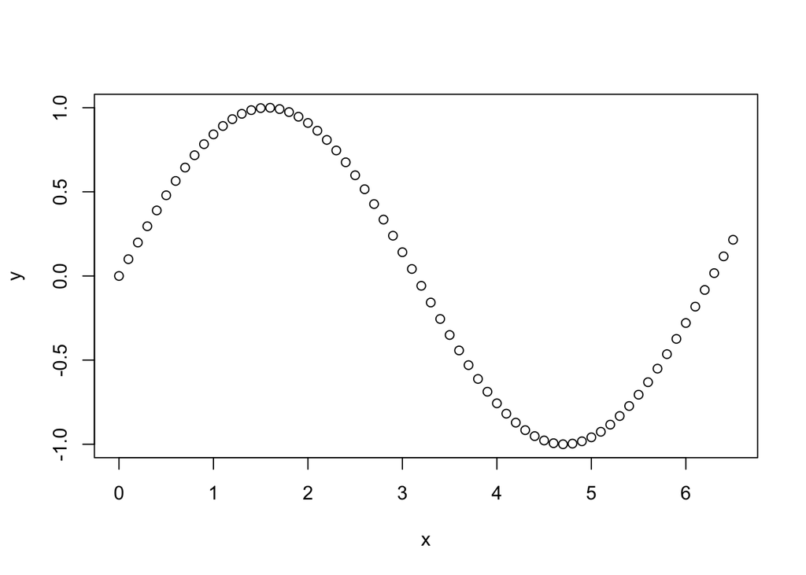

```r
x = seq(0,6.5, 0.1)  #this creates a numeric vector from 0 to 6.5 by increments of 0.1
y = sin(x)  #this takes the sin(x)
plot(y~x)
```

Note also – as shown above – that if you don’t specify a title or *x* or *y* axis labels, that’s OK… the plot just is a bit boring, but **R** still makes the plot for you.

### Customizing plots

#### Scale

You might want to play with the x- or y-scales. Keeping our same plot as above, we can do this easily with the arguments *ylim()* and *xlim()* by providing a two-number vector: the min and max you want to see shown on the graph.

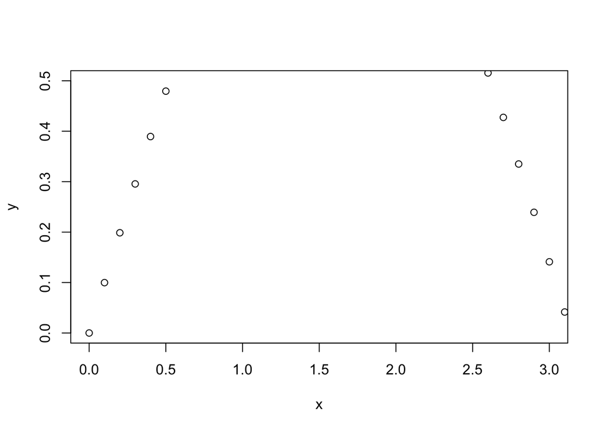

```r
plot(y~x,
     ylim=c(0,0.5),
     xlim=c(0,3)
     )
```

#### Plotting Character

Now, let’s say you want to plot in squares instead of circles. Sure. You can do that. Or filled circles. Or whatever. There’s an argument for that, called *pch*, which stands for “plot character”.

Using the code from the *Pirate’s Guide*:

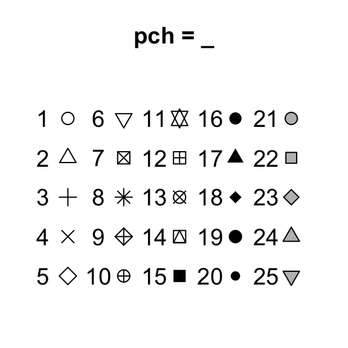

The symbol types associated with the pch plotting parameter.

And you can even decide you want to plot using letters or other character strings, by giving *pch* a character instead of a numeral. For example, if today we really like the letter W…

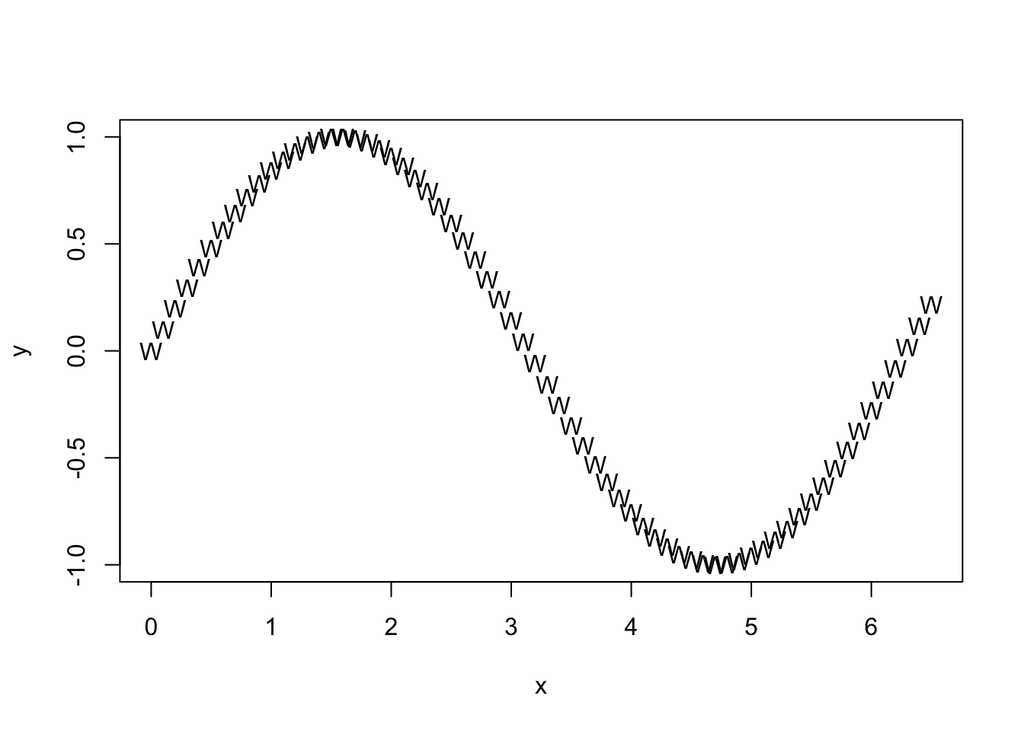

```r
plot(y~x,
     pch="W"
     )
```

#### Color

**R** has infinite color options; some are built-in, and you can generate new ones yourself. To borrow again from the *Pirate’s Guide*:

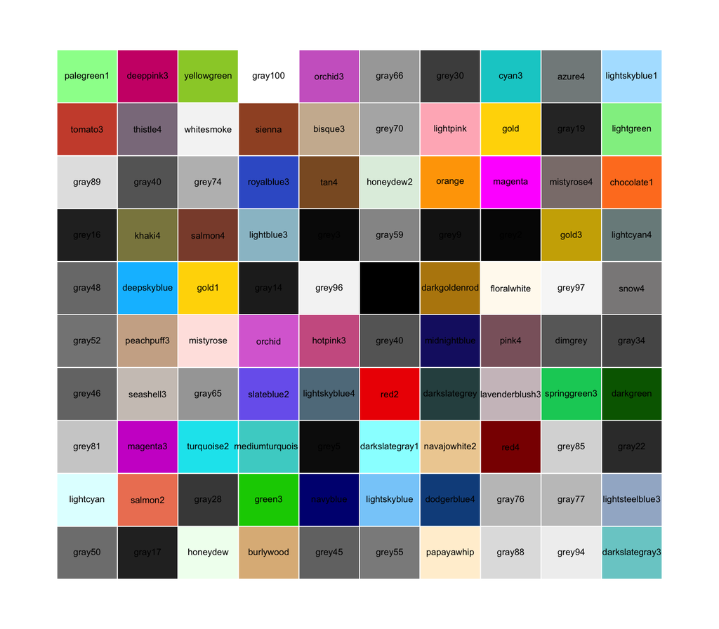

100 random named colors (out of all 657) in R.

> To see all 657 color names in R, run the code `colors()`. Or to see an interactive demo of colors, run `demo("colors")`.

Some awesome people have created color palettes based on movies, directors, etc. The *wesanderson* set of palettes might be my favorite. For example:

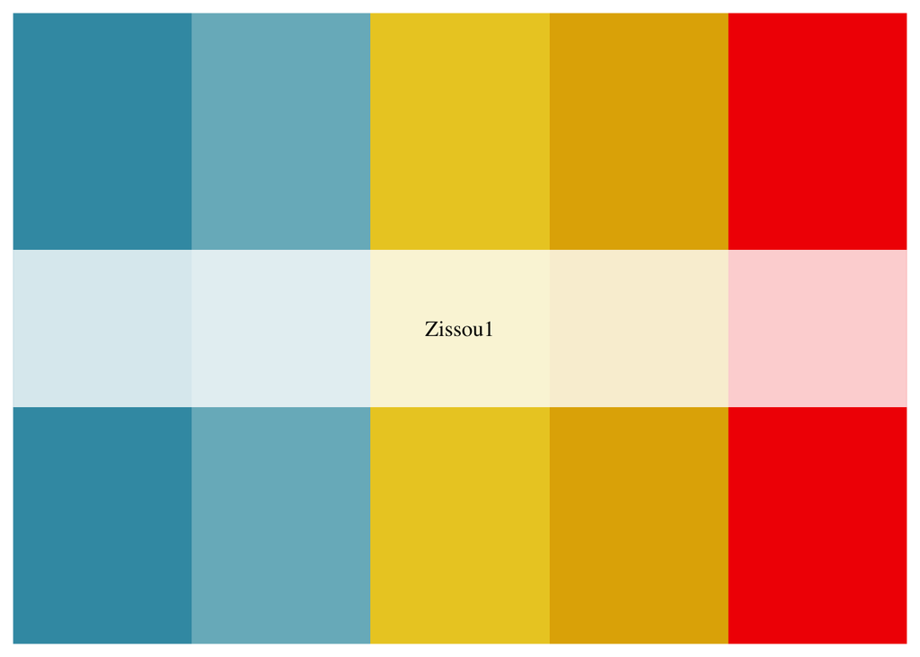

```r
library(wesanderson)

wes_palette("Zissou1")  #show the colors in the wesanderson palette "Zissou1"
```

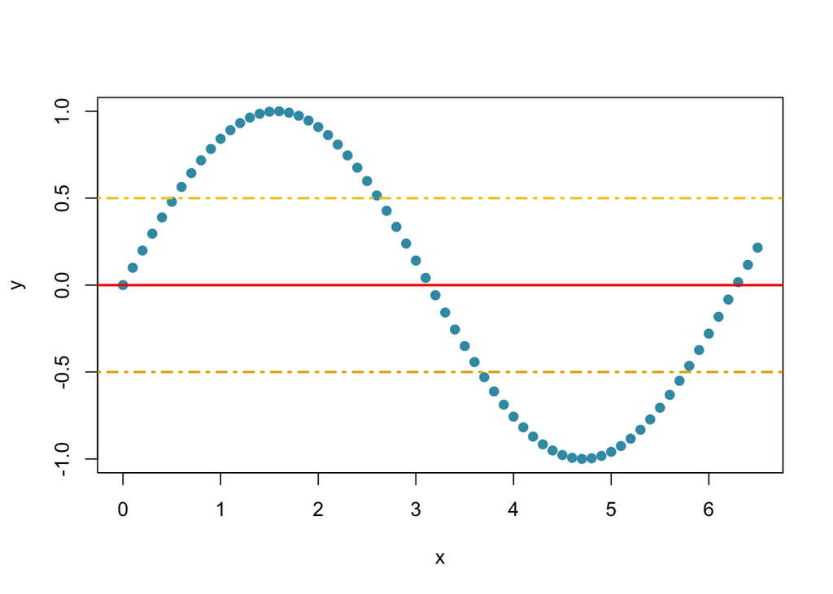

```r
plot(y~x,
     col=wes_palette("Zissou1")[1],
     pch=19) #make the sine plot, but using the first Zissou1 color and use solid circles as the plot character
abline(h=0,
      col=wes_palette("Zissou1")[5],
      lwd = 2) #draw a horizontal line at y = 0, using a Zissou1 color
abline(h=0.5,
      col=wes_palette("Zissou1")[3],
      lwd = 2,
      lty = 4) #draw a horizontal line at y = 0.5, using a Zissou1 color, and make it a dashed line (lty ... "for line type")
abline(h=-0.5,
      col=wes_palette("Zissou1")[4],
      lwd = 2,
      lty = 4) #draw a horizontal line at y = -0.5, using a Zissou1 color, and make it a dashed line (lty ... "for line type")
```

#### Many more parameters

See ?par for the complete set of base **R** plotting parameters. You can change just about anything about a graph: font, margins, rotation of labels, etc.

### Non-Scatterplots

Life isn’t all about scatterplots, of course. Let’s see some other useful kinds of plots, again quoting from the *Pirate’s Guide*:

> Histogram: `hist()`

| Argument | Description |
| --- | --- |
| `x` | Vector of values |
| `breaks` | How should the bin sizes be calculated? Can be specified in many ways (see `?hist` for details) |
| `freq` | Should frequencies or probabilities be plotted? `freq = TRUE` shows frequencies, `freq = FALSE` shows probabilities. |
| `col`, `border` | Colors of the bin filling (`col`) and border (`border`) |

> Histograms are the most common way to plot a vector of numeric data. To create a histogram we’ll use the `hist()` function. The main argument to `hist()` is a `x`, a vector of numeric data. If you want to specify how the histogram bins are created, you can use the `breaks` argument. To change the color of the border or background of the bins, use `col` and `border`:

> Let’s create a histogram of the weights in the ChickWeight dataset:

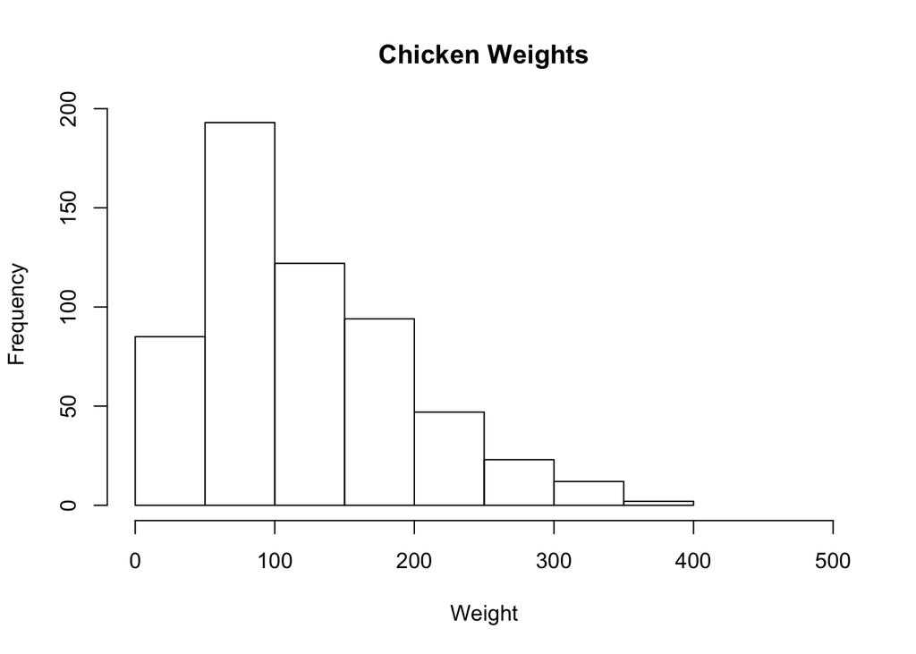

```r
hist(x = ChickWeight$weight,
     main = "Chicken Weights",
     xlab = "Weight",
     xlim = c(0, 500))
```

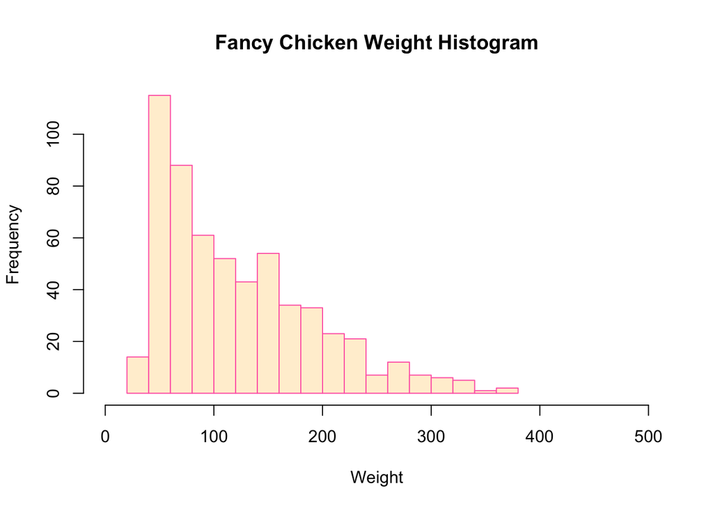

```r
hist(x = ChickWeight$weight,
     main = "Fancy Chicken Weight Histogram",
     xlab = "Weight",
     ylab = "Frequency",
     breaks = 20, # 20 Bins
     xlim = c(0, 500),
     col = "papayawhip", # Filling Color
     border = "hotpink") # Border Color
```

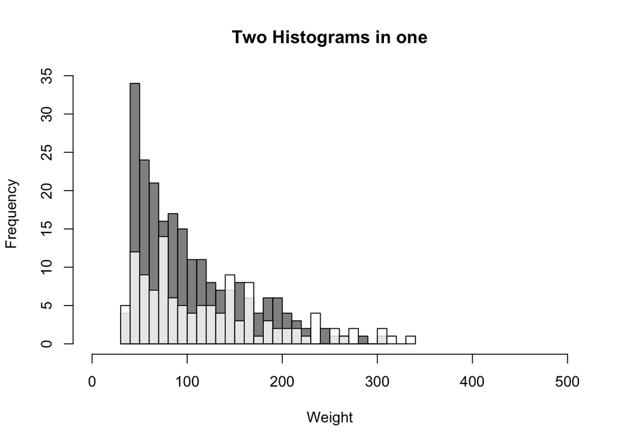

```r
hist(x = ChickWeight$weight[ChickWeight$Diet == 1],
     main = "Two Histograms in one",
     xlab = "Weight",
     ylab = "Frequency",
     breaks = 20,
     xlim = c(0, 500),
     col = gray(0, .5))

hist(x = ChickWeight$weight[ChickWeight$Diet == 2],
     breaks = 30,
     add = TRUE, # Add plot to previous one!
     col = gray(1, .8))
```

#### And More

You get the point. For any plot you can imagine (and more), there’s a way to do it in **R**. People have created additional packages for things like *waffleplots* , *network diagrams* and all kinds of things.

### ggplot2

We’re going to look more at this in two weeks, but just as a quick preview, there are other packages for **R** that people have created to create graphics in different ways. One of those is *ggplot2*, which has different syntax, and can make cool things like this:

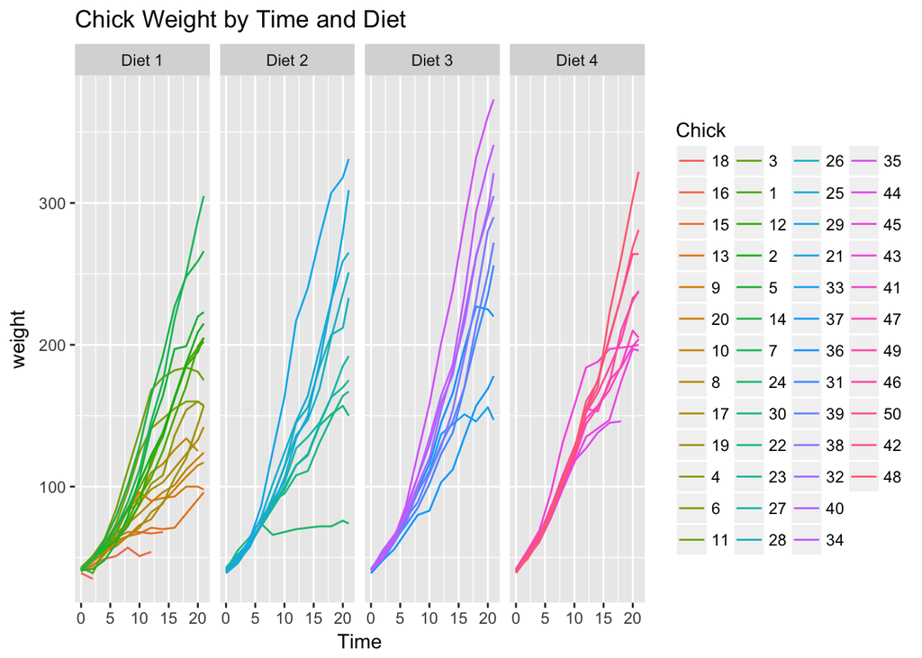

```r
library(ggplot2)
levels(ChickWeight$Diet)<-c("Diet 1", "Diet 2", "Diet 3", "Diet 4")  #relabel Diet categories for clarity in graphing
  ggplot(data = ChickWeight, aes(x=Time, y=weight, color=Chick))+
    geom_line()+
    facet_grid(~Diet)+
    guides(color=guide_legend(ncol=4))+
    labs(color="Chick")+
    ggtitle("Chick Weight by Time and Diet")
```